# BlackFriday Analysis

Nisha Selvarajan

11/1/2020

## BlackFriday - Customer Purchasing Behavior

*Market Basket Analysis /APRIORI - Black Friday Examined*

With the holiday season fast approaching, I found it intriguing to examine a dataset revolving around a hypothetical store and data of its shoppers.Ability to recognize and track patterns in data help businesses shift through the layers of seemingly unrelated data for meaningful relationships. Through this analysis it becomes easy for the online retailers to determine the dimensions that influence the uptake of online shopping and plan effective marketing strategies. This project builds a roadmap for analyzing consumer’s online buying behavior with the help of Apriori algorithm.

Your client gives you data for all transactions that consists of items bought in the store by several customers over a period of time and asks you to use that data to help boost their business. Your client will use your findings to not only change/update/add items in inventory but also use them to change the layout of the physical store or rather an online store. To find results that will help your client, you will use Market Basket Analysis (MBA) which uses Association Rule Mining on the given transaction data.

## Association Rule Mining

- Association Rule Mining is used when you want to find an association between different objects in a set, find frequent patterns in a transaction database, relational databases or any other information repository. The applications of Association Rule Mining are found in Marketing, Basket Data Analysis (or Market Basket Analysis) in retailing, clustering and classification. It can tell you what items do customers frequently buy together by generating a set of rules called Association Rules. In simple words, it gives you output as rules in form if this then that. Clients can use those rules for numerous marketing strategies:
  - Changing the store layout according to trends
  - Customer behavior analysis -Catalogue design -Cross marketing on online stores -What are the trending items customers buy -Customized emails with add-on sales
- Association Rule Mining is viewed as a two-step approach:

  -Frequent Itemset Generation: Find all frequent item-sets with support >= pre-determined min_support count. Frequent Itemset Generation is the most computationally expensive step because it requires a full database scan.

  -Rule Generation: List all Association Rules from frequent item-sets. Calculate Support and Confidence for all rules. Prune rules that fail min_support and min_confidence thresholds.

### Challenge

- Find hidden relationships between the products ,and to analyze purchase behaviors using APRIORI.
- Look for combinations of items that occur together frequently in transactions, providing information to understand the purchase behavior. The outcome of this type of technique is, in simple terms, a set of rules that can be understood as “if this, then that”

### Data Description

- The data used for this particular project is “Black Friday Sales Analysis”(https://www.kaggle.com/mehdidag/black-friday). Detailed description of the variables:

| Names | Description |
| --- | --- |
| User_ID | Categorical - User ID |
| Product_ID | Categorical - Product ID |
| Gender | Categorical - Sex of User |
| Age | Categorical - Age in bins |
| Occupation | Categorical - Occupation (Masked) |
| City_Category | Categorical - Category of the City (A,B,C) |
| Stay_In_Current_City_Years | Numerical - Number of years stay in current city |
| Marital_Status | Categorical - Marital Status |
| Product_Category_1 | Categorical - Product Category (Masked) |
| Product_Category_2 | Categorical - Product may belongs to other category also (Masked) |
| Product_Category_3 | Categorical - Product may belong to other category also (Masked) |
| Purchase | Numerical - Purchase Amount (Target Variable) |

### Data Analysis & Clean up

- Black Friday data set is further cleaned by changing the format of each variable. This included changing Product_ID, Gender, Age, City_Category, Marital_Status and Product_Category from character variables to factors.
- Product Category 2 & Product Category 3 has many missing values. Input 0 for Product Category 2/ Product Category 3.

### Exploratory Data Analysis

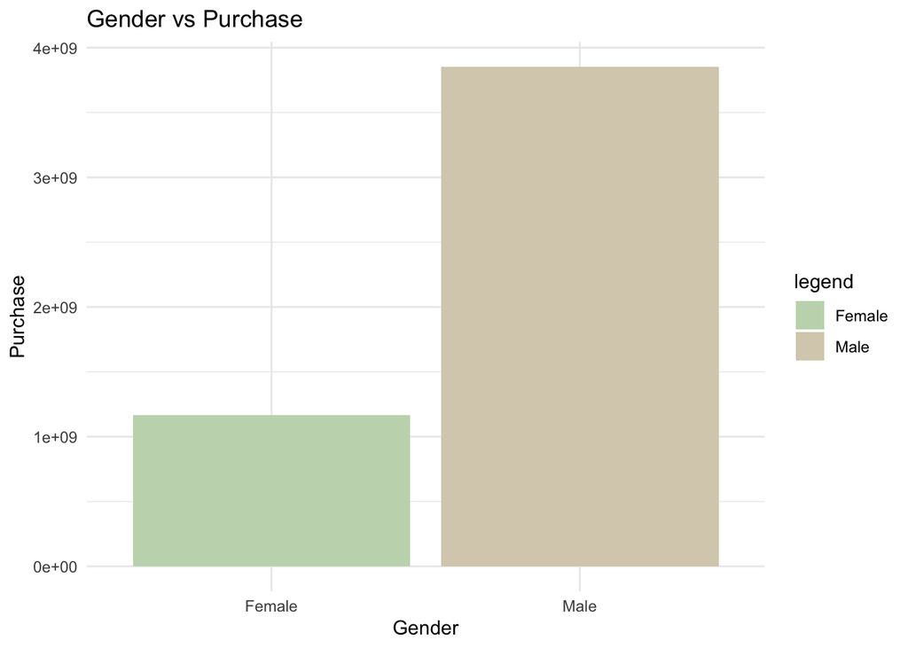

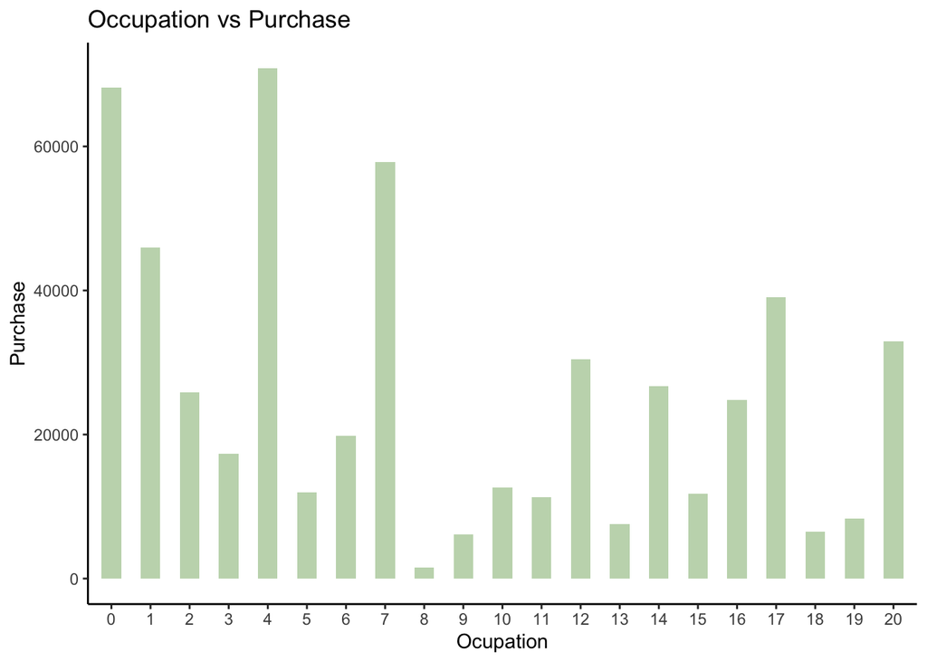

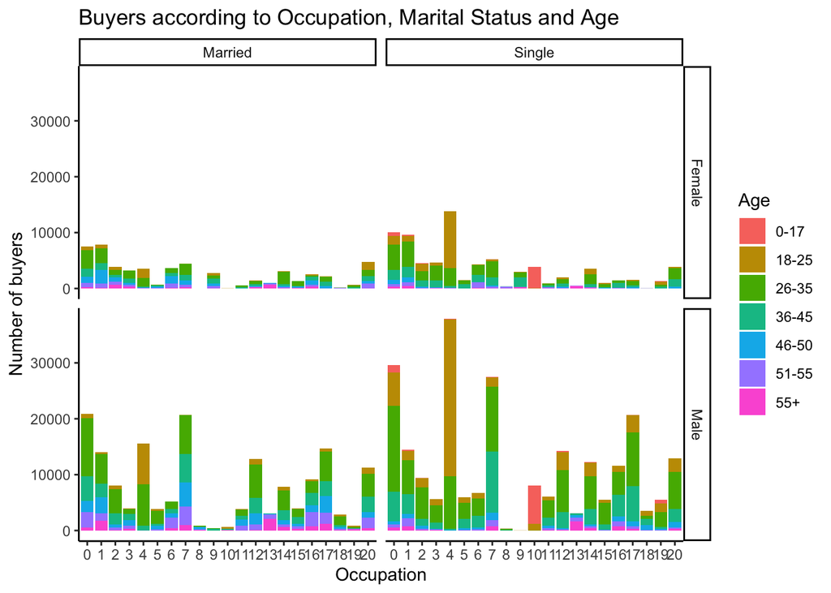

```
##
##         0     1     2     3    4+
##   A 23700 48160 26548 24389 21841
##   B 28143 81622 40800 41964 33964
##   C 20882 59410 32111 26959 27084
```

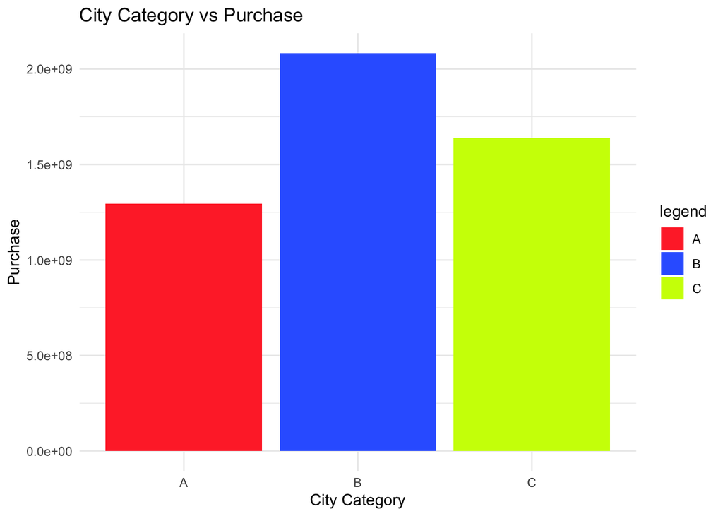

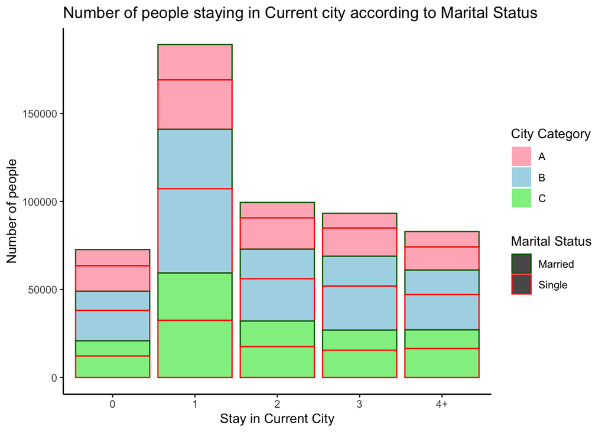

[figure not shown]

[figure not shown]

```
## , ,  = 0-17
##
##
##           Female   Male
##   Married      0      0
##   Single    4953   9754
##
## , ,  = 18-25
##
##
##           Female   Male
##   Married   6117  14524
##   Single   17940  59053
##
## , ,  = 26-35
##
##
##           Female   Male
##   Married  19959  64207
##   Single   29389 101135
##
## , ,  = 36-45
##
##
##           Female   Male
##   Married  10115  32392
##   Single   16305  48687
##
## , ,  = 46-50
##
##
##           Female   Male
##   Married   9797  22397
##   Single    3059   9273
##
## , ,  = 51-55
##
##
##           Female   Male
##   Married   6150  20829
##   Single    3484   7155
##
## , ,  = 55+
##
##
##           Female   Male
##   Married   3085  10188
##   Single    1844   5786
```

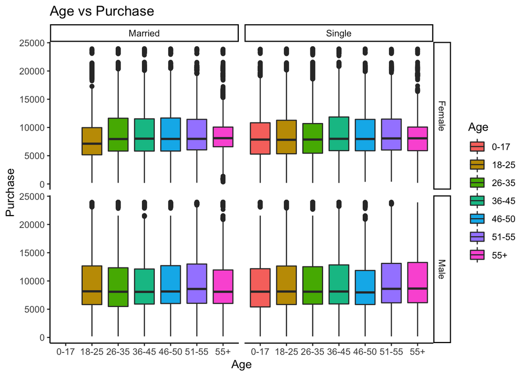

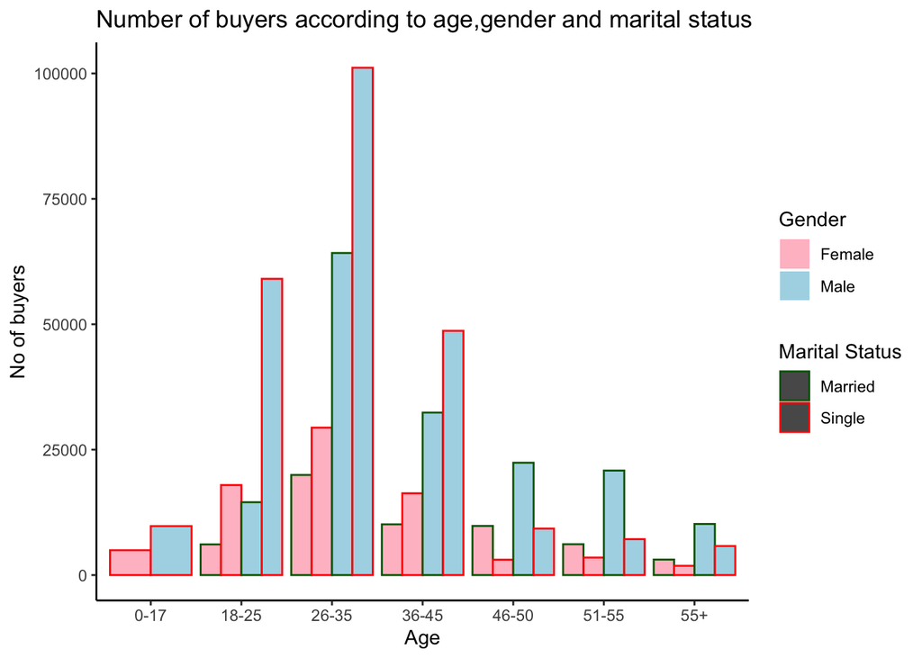

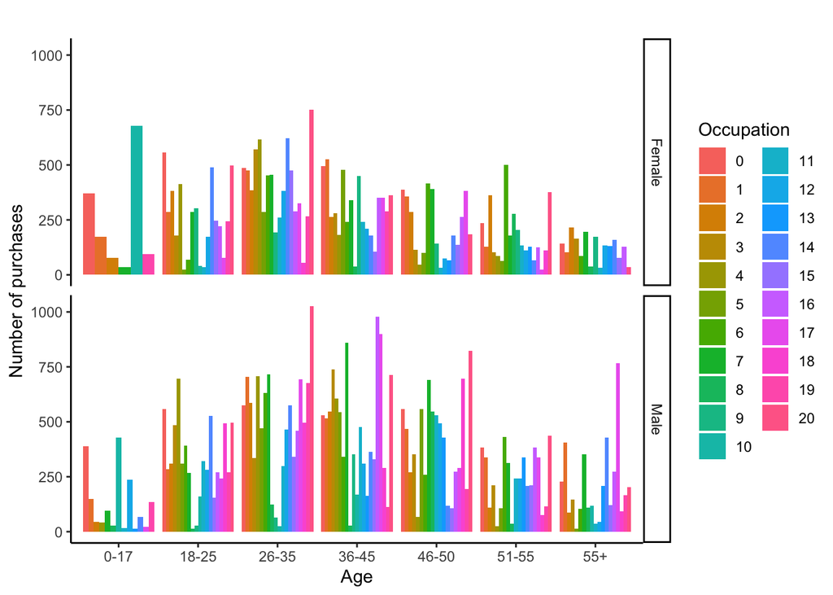

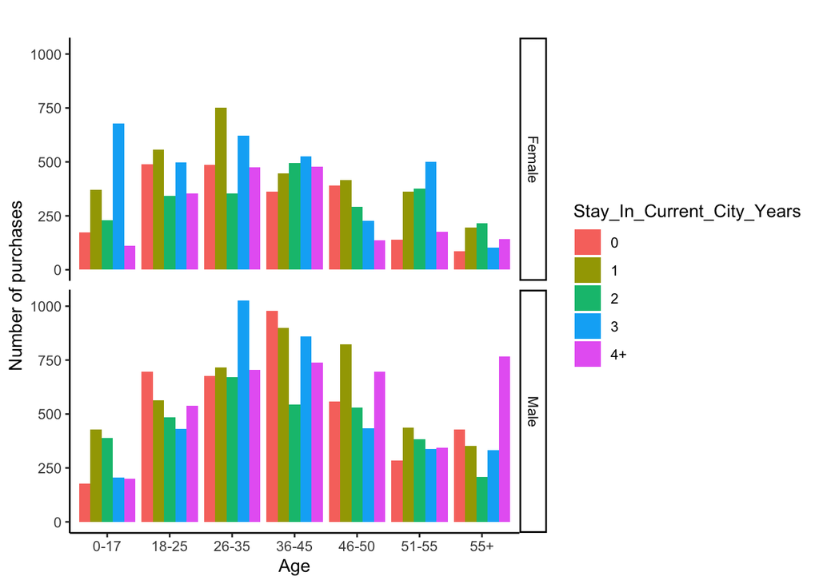

### Frequency Distribution By Product Category

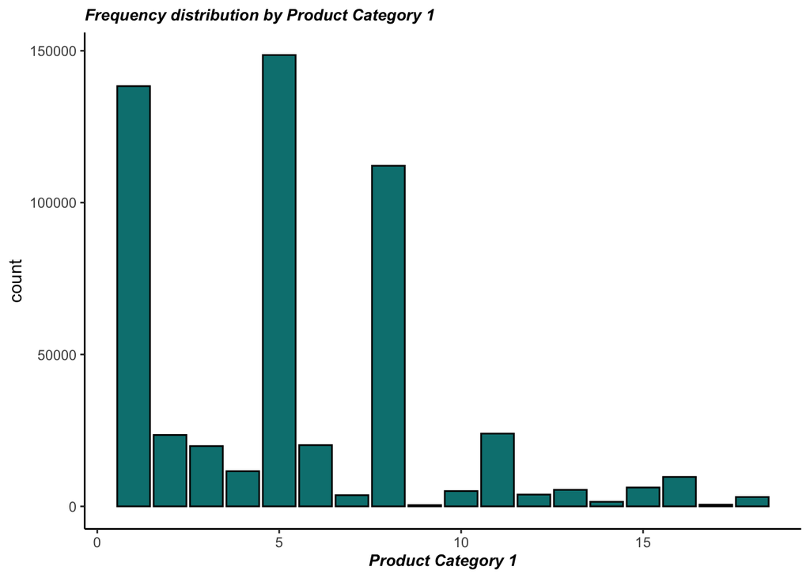

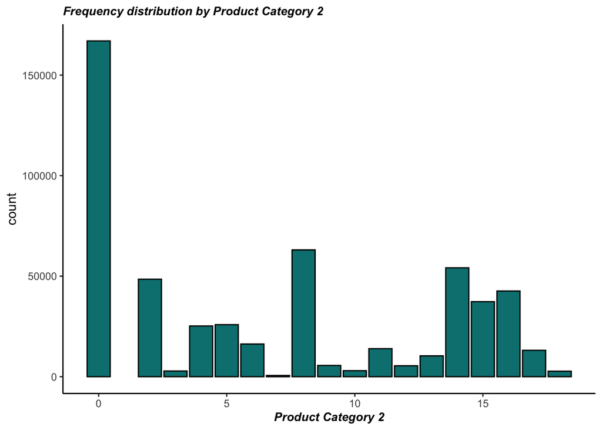

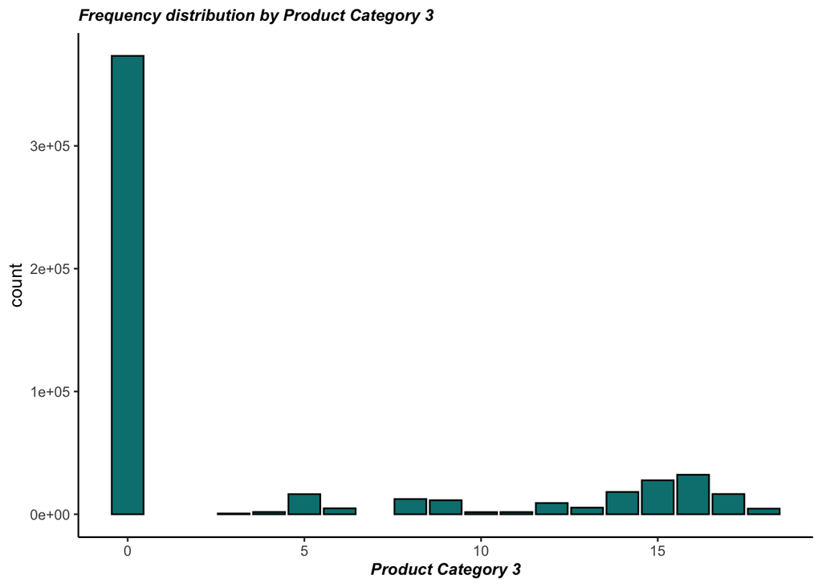

### Impleentation of APRIORI

- Step 1: Load the dataset & Clean the dataset.

```
## transactions as itemMatrix in sparse format with
##  537578 rows (elements/itemsets/transactions) and
##  537578 columns (items) and a density of 1.860195e-06
##
## most frequent items:
##  1000001,P00000142,F,0-17,10,A,2,0,3,4,5,13650
##                                              1
## 1000001,P00004842,F,0-17,10,A,2,0,3,4,12,13645
##                                              1
##  1000001,P00025442,F,0-17,10,A,2,0,1,2,9,15416
##                                              1
##   1000001,P00051442,F,0-17,10,A,2,0,8,17,,9938
##                                              1
##    1000001,P00051842,F,0-17,10,A,2,0,4,8,,2849
##                                              1
##                                        (Other)
##                                         537573
##
## element (itemset/transaction) length distribution:
## sizes
##      1
## 537578
##
##    Min. 1st Qu.  Median    Mean 3rd Qu.    Max.
##       1       1       1       1       1       1
##
## includes extended item information - examples:
##                                           labels
## 1  1000001,P00000142,F,0-17,10,A,2,0,3,4,5,13650
## 2 1000001,P00004842,F,0-17,10,A,2,0,3,4,12,13645
## 3  1000001,P00025442,F,0-17,10,A,2,0,1,2,9,15416
```

- Step 2: Data cleaning and manipulations using R.
  - Group the transactions by USER ID. The data required for Apriori must be in the basket format.The basket format must have first column as a unique identifier of each transaction, something like a unique product Id. The second columns consists of the items bought in that transaction, separated by spaces or commas or some other separator.
- APRIORI needs the data in transaction format. Convert grouped customer Id data frame to transaction.
- read.transactions in R reads a transaction data file from disk and creates a transactions object.

[output not shown]

[output cut: 47 more lines]

### Item Frequency Plot

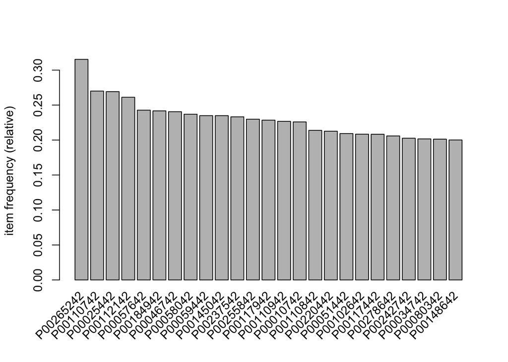

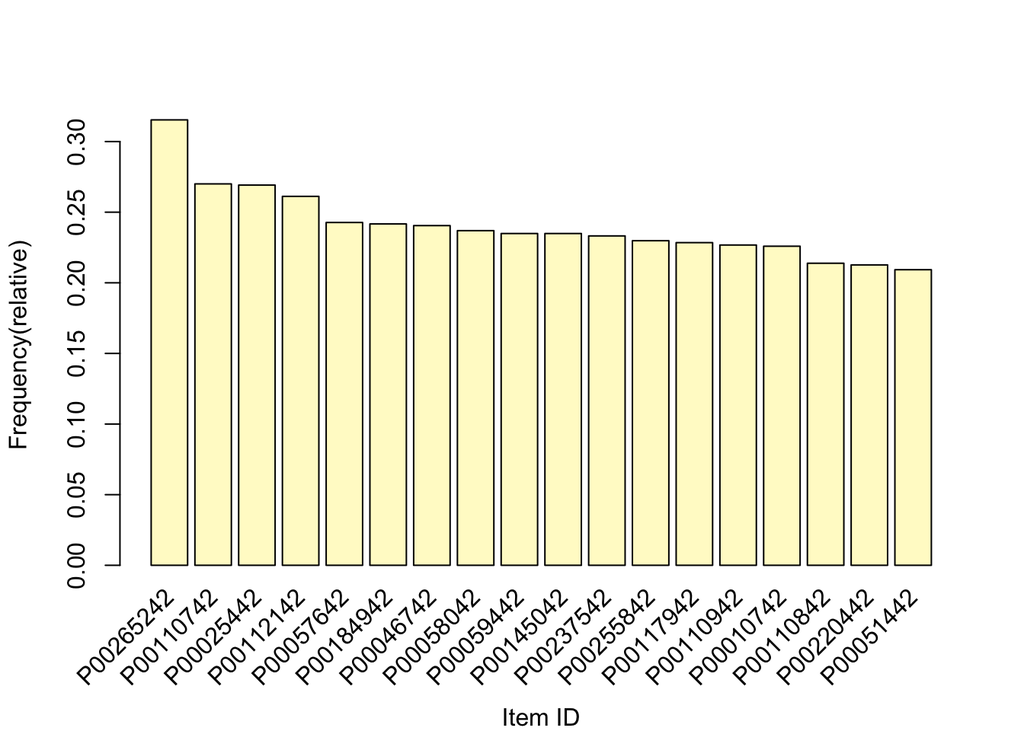

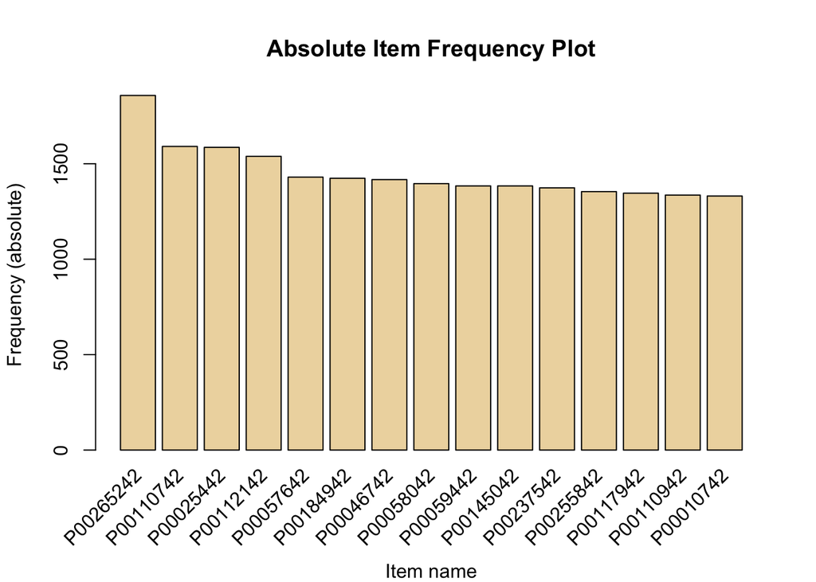

- Step 3: Find the association rules.
  - Next step is to mine the rules using the APRIORI algorithm. The function apriori() is from package arules.
  - Association rules analysis is a technique to uncover how items are associated to each other. There are three common ways to measure association.
  - Measure 1: Support. This says how popular an itemset is, as measured by the proportion of transactions in which an itemset appears.
  - Measure 2: Confidence. This says how likely item Y is purchased when item X is purchased, expressed as {X -> Y}. This is measured by the proportion of transactions with item X, in which item Y also appears.
  - Measure 3: Lift. This says how likely item Y is purchased when item X is purchased, while controlling for how popular item Y is.
  - Measure 4:minlen is the minimum number of items required in the rule.
  - Measure 5:maxlen is the maximum number of items that can be present in the rule.

```r
summary(itemFrequency(customers_products))
```

```
##      Min.   1st Qu.    Median      Mean   3rd Qu.      Max.
## 0.0001697 0.0001697 0.0001697 0.0087686 0.0037339 0.3153428
```

```r
rules = apriori(data = customers_products, parameter = list(support =
                                                              0.01, confidence = 0.74, minlen = 4))
```

```
## Apriori
##
## Parameter specification:
##  confidence minval smax arem  aval originalSupport maxtime support minlen
##        0.74    0.1    1 none FALSE            TRUE       5    0.01      4
##  maxlen target  ext
##      10  rules TRUE
##
## Algorithmic control:
##  filter tree heap memopt load sort verbose
##     0.1 TRUE TRUE  FALSE TRUE    2    TRUE
##
## Absolute minimum support count: 58
##
## set item appearances ...[0 item(s)] done [0.00s].
## set transactions ...[10539 item(s), 5892 transaction(s)] done [0.17s].
## sorting and recoding items ... [1958 item(s)] done [0.02s].
## creating transaction tree ... done [0.00s].
## checking subsets of size 1 2 3 4 done [8.04s].
## writing ... [10 rule(s)] done [0.07s].
## creating S4 object  ... done [0.17s].
```

- Step 5: Print the association rules. To print the association rules, we use a function called inspect().

```r
inspect(rules[1:10])
```

```
##      lhs                                rhs         support    confidence
## [1]  {P00057642,P00105142,P00127342} => {P00025442} 0.01154107 0.7640449
## [2]  {P00025442,P00034042,P00112442} => {P00110742} 0.01001358 0.7468354
## [3]  {P00034042,P00057942,P00112542} => {P00110742} 0.01052274 0.7469880
## [4]  {P00034042,P00111142,P00112542} => {P00110742} 0.01052274 0.7469880
## [5]  {P00003242,P00111142,P00127842} => {P00145042} 0.01120163 0.7857143
## [6]  {P00057942,P00105142,P00182242} => {P00110742} 0.01086219 0.7529412
## [7]  {P00111742,P00295942,P00323942} => {P00052842} 0.01052274 0.7469880
## [8]  {P00128942,P00144642,P00329542} => {P00057642} 0.01001358 0.7763158
## [9]  {P00070042,P00117942,P00277642} => {P00145042} 0.01137135 0.7613636
## [10] {P00000142,P00086442,P00140742} => {P00145042} 0.01018330 0.7407407
##      coverage   lift     count
## [1]  0.01510523 2.838432 68
## [2]  0.01340801 2.765779 59
## [3]  0.01408690 2.766344 62
## [4]  0.01408690 2.766344 62
## [5]  0.01425662 3.344963 66
## [6]  0.01442634 2.788391 64
## [7]  0.01408690 4.546749 62
## [8]  0.01289885 3.198638 59
## [9]  0.01493551 3.241297 67
## [10] 0.01374745 3.153500 60
```

- Sort by Confidence

```r
inspect(sort(rules, by = 'confidence'))
```

```
##      lhs                                rhs         support    confidence
## [1]  {P00003242,P00111142,P00127842} => {P00145042} 0.01120163 0.7857143
## [2]  {P00128942,P00144642,P00329542} => {P00057642} 0.01001358 0.7763158
## [3]  {P00057642,P00105142,P00127342} => {P00025442} 0.01154107 0.7640449
## [4]  {P00070042,P00117942,P00277642} => {P00145042} 0.01137135 0.7613636
## [5]  {P00057942,P00105142,P00182242} => {P00110742} 0.01086219 0.7529412
## [6]  {P00034042,P00057942,P00112542} => {P00110742} 0.01052274 0.7469880
## [7]  {P00034042,P00111142,P00112542} => {P00110742} 0.01052274 0.7469880
## [8]  {P00111742,P00295942,P00323942} => {P00052842} 0.01052274 0.7469880
## [9]  {P00025442,P00034042,P00112442} => {P00110742} 0.01001358 0.7468354
## [10] {P00000142,P00086442,P00140742} => {P00145042} 0.01018330 0.7407407
##      coverage   lift     count
## [1]  0.01425662 3.344963 66
## [2]  0.01289885 3.198638 59
## [3]  0.01510523 2.838432 68
## [4]  0.01493551 3.241297 67
## [5]  0.01442634 2.788391 64
## [6]  0.01408690 2.766344 62
## [7]  0.01408690 2.766344 62
## [8]  0.01408690 4.546749 62
## [9]  0.01340801 2.765779 59
## [10] 0.01374745 3.153500 60
```

- Sort by Lift

```r
inspect(sort(rules, by = 'lift'))
```

```
##      lhs                                rhs         support    confidence
## [1]  {P00111742,P00295942,P00323942} => {P00052842} 0.01052274 0.7469880
## [2]  {P00003242,P00111142,P00127842} => {P00145042} 0.01120163 0.7857143
## [3]  {P00070042,P00117942,P00277642} => {P00145042} 0.01137135 0.7613636
## [4]  {P00128942,P00144642,P00329542} => {P00057642} 0.01001358 0.7763158
## [5]  {P00000142,P00086442,P00140742} => {P00145042} 0.01018330 0.7407407
## [6]  {P00057642,P00105142,P00127342} => {P00025442} 0.01154107 0.7640449
## [7]  {P00057942,P00105142,P00182242} => {P00110742} 0.01086219 0.7529412
## [8]  {P00034042,P00057942,P00112542} => {P00110742} 0.01052274 0.7469880
## [9]  {P00034042,P00111142,P00112542} => {P00110742} 0.01052274 0.7469880
## [10] {P00025442,P00034042,P00112442} => {P00110742} 0.01001358 0.7468354
##      coverage   lift     count
## [1]  0.01408690 4.546749 62
## [2]  0.01425662 3.344963 66
## [3]  0.01493551 3.241297 67
## [4]  0.01289885 3.198638 59
## [5]  0.01374745 3.153500 60
## [6]  0.01510523 2.838432 68
## [7]  0.01442634 2.788391 64
## [8]  0.01408690 2.766344 62
## [9]  0.01408690 2.766344 62
## [10] 0.01340801 2.765779 59
```

- Step 6: Plot a few graphs that can help you visualize the rules

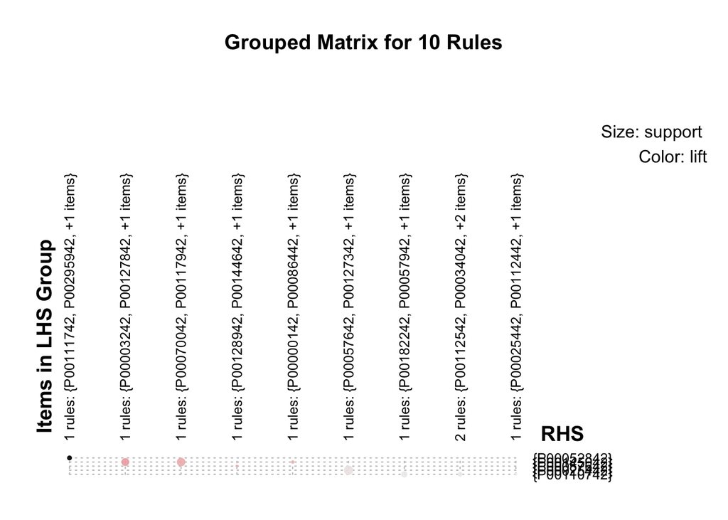

```r
 library(arulesViz)
 library(arules)
 plot(rules, method = 'grouped', max = 4)
```

- Scatter Plot for the rules.

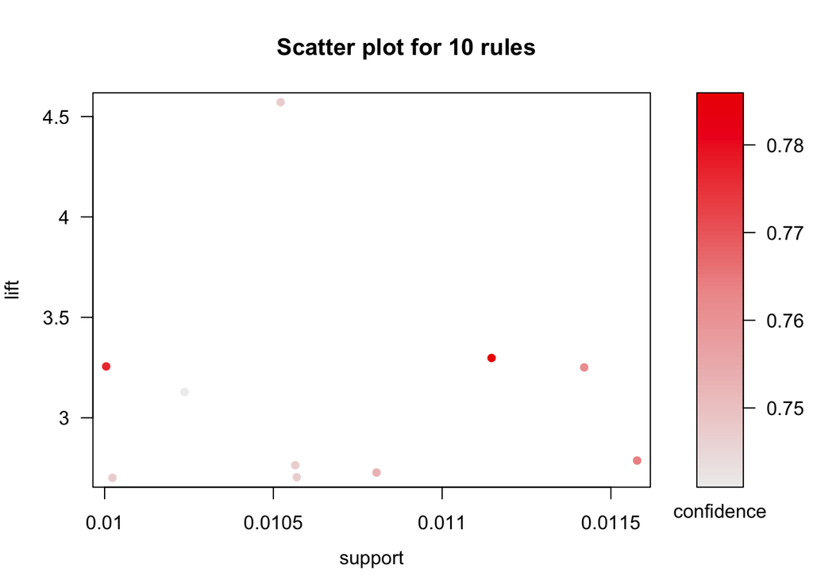

```r
 plot(rules,measure = c("support","lift"),shading = "confidence",jitter = 2)
```

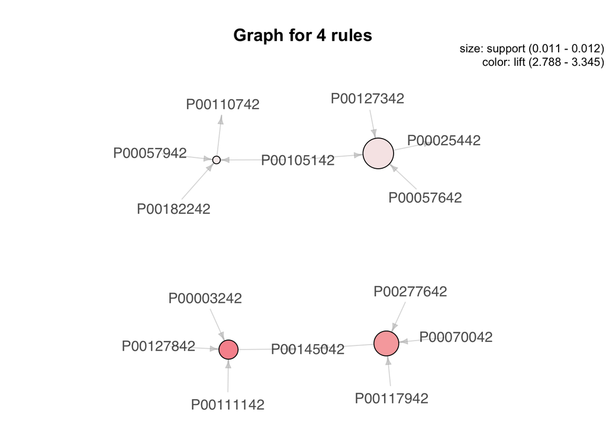

```r
 plot(rules, method="graph",max = 4)
```

### What rules lead to consequent?

- This can be done by filtering the rules to see what leads to a particular product

```r
filter = 'P00110742'
rules_filtered <- subset(rules, subset = rhs %in% filter)

inspect(rules_filtered)
```

```
##     lhs                                rhs         support    confidence
## [1] {P00025442,P00034042,P00112442} => {P00110742} 0.01001358 0.7468354
## [2] {P00034042,P00057942,P00112542} => {P00110742} 0.01052274 0.7469880
## [3] {P00034042,P00111142,P00112542} => {P00110742} 0.01052274 0.7469880
## [4] {P00057942,P00105142,P00182242} => {P00110742} 0.01086219 0.7529412
##     coverage   lift     count
## [1] 0.01340801 2.765779 59
## [2] 0.01408690 2.766344 62
## [3] 0.01408690 2.766344 62
## [4] 0.01442634 2.788391 64
```